# F9_03_PROG_EXP

Program accomplishment expenses · Amount report

## Overview

**Description**

Program Accomplishment Expenses

**Table**

**Location code**

`F990-PC-PART-03-LINE-04-ABCD`, `F990-EZ-PART-03-LINE-28A-31A`

**Family**

`F990-PC-PART-03-LINE-04-ABCD` · siblings: F9_03_PROG_CODE, F9_03_PROG_DESC, F9_03_PROG_GRANT, F9_03_PROG_REV, F9_03_PROG_EXP_OTH_TOT, F9_03_PROG_GRANT_OTH_TOT

**Data type**

numeric (xsd: USAmountType, , USAmountNNType)

**Scope**

PZ

**Status**

unreviewed

15

xpaths mapped (10 observed)

6,825,744

filings with a value

2009–2024

tax years observed

15

open flags (1 errors)

## Flags

| Severity | Flag | Xpath | Detail |
| --- | --- | --- | --- |
| ⚠ error | `COLLISION` | IRS990/ExpenseAmt | 1037186 filings contain 2+ of its xpaths; most common set: /Return/ReturnData/IRS990/ExpenseAmt ; /Return/ReturnData/IRS990/ProgSrvcAccomActy2Grp/ExpenseAmt ; /Return/ReturnData/IRS990/ProgSrvcAccomAc… |
| ▲ warn | `GAP` |  | no filings in 2019,2020,2023, but filings before and after |
| ▲ warn | `GAP` |  | no filings in 2022-2023, but filings before and after |
| ▲ warn | `GAP` |  | no filings in 2022-2023, but filings before and after |
| ▲ warn | `INCIDENCE_BREAK` |  | 990 fill rate changes up to 8.7x year-on-year (in 2010-2024) |
| ▲ warn | `INCIDENCE_BREAK` |  | 990 fill rate changes up to 5.0x year-on-year (in 2009-2024) |
| ⓘ info | `MANY_NOT_REPEATING` | IRS990EZ/ProgramSrvcAccomplishmentGrp/ProgramServiceExpensesAmt | many-to-one table, but 68% of values sit in no repeating element |
| ⓘ info | `MANY_NOT_REPEATING` | IRS990/ProgSrvcAccomActyOtherGrp/ExpenseAmt | many-to-one table, but 85% of values sit in no repeating element |
| ⓘ info | `MANY_NOT_REPEATING` | IRS990EZ/ProgramServiceAccomplishment/ProgramServiceExpenses | many-to-one table, but 69% of values sit in no repeating element |
| ⓘ info | `MANY_NOT_REPEATING` | IRS990/ActivityOther/Expense | many-to-one table, but 81% of values sit in no repeating element |
| ⓘ info | `UNOBSERVED` | IRS990/Form990PartIII/Activity2/Expense | never observed in TY2009-2024 filings |
| ⓘ info | `UNOBSERVED` | IRS990/Form990PartIII/Activity3/Expense | never observed in TY2009-2024 filings |
| ⓘ info | `UNOBSERVED` | IRS990/Form990PartIII/ActivityOther/Expense | never observed in TY2009-2024 filings |
| ⓘ info | `UNOBSERVED` | IRS990/Form990PartIII/Expense | never observed in TY2009-2024 filings |
| ⓘ info | `UNOBSERVED` | IRS990/ProgramServiceAccomplishments/ProgramServiceExpenses | never observed in TY2009-2024 filings |

## Xpaths

All mapped xpaths (under /Return/ReturnData or /Return/ReturnHeader), oldest first. Charts label each series by its xpath.

| Xpath | Form | Chart label | First year | Last year | Versions | Filings | Repeats in |
| --- | --- | --- | --- | --- | --- | --- | --- |
| IRS990/Expense | 990 | same | 2009 | 2012 | 19 | 423,499 | 0.0% |
| IRS990EZ/ProgramServiceAccomplishment/ProgramServiceExpenses | 990-EZ | same | 2009 | 2012 | 18 | 177,997 | 27.0% |
| IRS990/Activity2/Expense | 990 | same | 2009 | 2012 | 18 | 136,442 | 0.0% |
| IRS990/Activity3/Expense | 990 | same | 2009 | 2012 | 18 | 97,520 | 0.0% |
| IRS990/ActivityOther/Expense | 990 | same | 2009 | 2012 | 17 | 57,666 | 17.3% |
| IRS990/ExpenseAmt | 990 | same | 2013 | 2024 | 38 | 2,823,270 | 0.0% |
| IRS990EZ/ProgramSrvcAccomplishmentGrp/ProgramServiceExpensesAmt | 990-EZ | …EZ/ProgramSrvcAccomplishmentGrp/ProgramServiceExpensesAmt | 2013 | 2024 | 37 | 1,338,629 | 27.9% |
| IRS990/Form990PartIII/Activity2/Expense | 990 | Other |  |  |  | 0 |  |
| IRS990/Form990PartIII/Activity3/Expense | 990 | Other |  |  |  | 0 |  |
| IRS990/Form990PartIII/ActivityOther/Expense | 990 | Other |  |  |  | 0 |  |
| IRS990/Form990PartIII/Expense | 990 | Other |  |  |  | 0 |  |
| IRS990/ProgSrvcAccomActy2Grp/ExpenseAmt | 990 | Other | 2013 | 2024 | 38 | 841,478 | 0.0% |
| IRS990/ProgSrvcAccomActy3Grp/ExpenseAmt | 990 | Other | 2013 | 2024 | 37 | 585,886 | 0.0% |
| IRS990/ProgSrvcAccomActyOtherGrp/ExpenseAmt | 990 | Other | 2013 | 2024 | 37 | 343,357 | 13.7% |
| IRS990/ProgramServiceAccomplishments/ProgramServiceExpenses | 990 | Other |  |  |  | 0 |  |

## Coverage

[figure not shown]

**Table view**

Table view: filings by tax year and series

| Tax year | IRS990/Expense | IRS990EZ/ProgramServiceAccomplishment/ProgramServiceExpenses | IRS990/Activity2/Expense | IRS990/Activity3/Expense | IRS990/ActivityOther/Expense | IRS990/ExpenseAmt | …EZ/ProgramSrvcAccomplishmentGrp/ProgramServiceExpensesAmt | Other |
| --- | --- | --- | --- | --- | --- | --- | --- | --- |
| 2009 | 30,060 | 11,785 | 11,315 | 8,622 | 5,046 | 0 | 0 | 0 |
| 2010 | 105,024 | 46,229 | 33,781 | 24,326 | 14,163 | 0 | 0 | 0 |
| 2011 | 135,755 | 57,608 | 43,315 | 30,752 | 17,841 | 0 | 0 | 0 |
| 2012 | 152,660 | 62,375 | 48,031 | 33,820 | 20,616 | 0 | 0 | 0 |
| 2013 | 0 | 0 | 0 | 0 | 0 | 168,629 | 69,766 | 111,470 |
| 2014 | 0 | 0 | 0 | 0 | 0 | 185,414 | 76,830 | 120,476 |
| 2015 | 0 | 0 | 0 | 0 | 0 | 197,332 | 82,235 | 126,706 |
| 2016 | 0 | 0 | 0 | 0 | 0 | 205,625 | 85,341 | 130,843 |
| 2017 | 0 | 0 | 0 | 0 | 0 | 220,497 | 90,520 | 138,847 |
| 2018 | 0 | 0 | 0 | 0 | 0 | 228,601 | 98,525 | 141,955 |
| 2019 | 0 | 0 | 0 | 0 | 0 | 239,293 | 101,322 | 147,646 |
| 2020 | 0 | 0 | 0 | 0 | 0 | 268,818 | 113,159 | 166,640 |
| 2021 | 0 | 0 | 0 | 0 | 0 | 282,624 | 151,459 | 174,696 |
| 2022 | 0 | 0 | 0 | 0 | 0 | 294,308 | 160,016 | 182,242 |
| 2023 | 0 | 0 | 0 | 0 | 0 | 299,706 | 160,274 | 185,794 |
| 2024 | 0 | 0 | 0 | 0 | 0 | 232,423 | 149,182 | 143,406 |

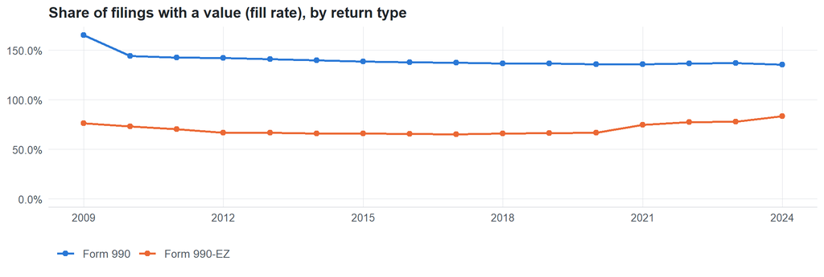

**Table view**

Table view: fill rate

| Tax year | Return type | Filings | All filings | Fill rate |
| --- | --- | --- | --- | --- |
| 2009 | Form 990 | 55,043 | 33,311 | 165.24% |
| 2009 | Form 990-EZ | 11,785 | 15,470 | 76.18% |
| 2010 | Form 990 | 177,294 | 123,025 | 144.11% |
| 2010 | Form 990-EZ | 46,229 | 63,326 | 73.00% |
| 2011 | Form 990 | 227,663 | 159,504 | 142.73% |
| 2011 | Form 990-EZ | 57,608 | 82,048 | 70.21% |
| 2012 | Form 990 | 255,127 | 179,688 | 141.98% |
| 2012 | Form 990-EZ | 62,375 | 93,750 | 66.53% |
| 2013 | Form 990 | 280,099 | 198,855 | 140.86% |
| 2013 | Form 990-EZ | 69,766 | 104,375 | 66.84% |
| 2014 | Form 990 | 305,890 | 218,619 | 139.92% |
| 2014 | Form 990-EZ | 76,830 | 116,417 | 66.00% |
| 2015 | Form 990 | 324,038 | 233,519 | 138.76% |
| 2015 | Form 990-EZ | 82,235 | 124,894 | 65.84% |
| 2016 | Form 990 | 336,468 | 243,903 | 137.95% |
| 2016 | Form 990-EZ | 85,341 | 130,484 | 65.40% |
| 2017 | Form 990 | 359,344 | 261,612 | 137.36% |
| 2017 | Form 990-EZ | 90,519 | 139,144 | 65.05% |
| 2018 | Form 990 | 370,556 | 271,442 | 136.51% |
| 2018 | Form 990-EZ | 98,525 | 149,384 | 65.95% |
| 2019 | Form 990 | 386,939 | 283,694 | 136.39% |
| 2019 | Form 990-EZ | 101,322 | 152,622 | 66.39% |
| 2020 | Form 990 | 435,458 | 320,342 | 135.94% |
| 2020 | Form 990-EZ | 113,159 | 169,864 | 66.62% |
| 2021 | Form 990 | 457,314 | 336,480 | 135.91% |
| 2021 | Form 990-EZ | 151,457 | 202,724 | 74.71% |
| 2022 | Form 990 | 476,546 | 349,055 | 136.52% |
| 2022 | Form 990-EZ | 160,014 | 206,130 | 77.63% |
| 2023 | Form 990 | 485,497 | 354,768 | 136.85% |
| 2023 | Form 990-EZ | 160,274 | 206,379 | 77.66% |
| 2024 | Form 990 | 375,825 | 277,298 | 135.53% |
| 2024 | Form 990-EZ | 149,181 | 178,867 | 83.40% |

## Repeating groups

Repeating element each xpath was observed in (from the raw indexed xpath)

| Xpath | Repeating element | Filings (summed over years) |
| --- | --- | --- |
| IRS990/Activity2/Expense | (none) | 136442 |
| IRS990/Activity3/Expense | (none) | 97520 |
| IRS990/ActivityOther/Expense | (none) | 46592 |
| IRS990/ActivityOther/Expense | IRS990/ActivityOther | 11074 |
| IRS990/Expense | (none) | 423499 |
| IRS990EZ/ProgramServiceAccomplishment/ProgramServiceExpenses | (none) | 122960 |
| IRS990EZ/ProgramServiceAccomplishment/ProgramServiceExpenses | IRS990EZ/ProgramServiceAccomplishment | 55037 |
| IRS990/ExpenseAmt | (none) | 2823270 |
| IRS990/ProgSrvcAccomActy2Grp/ExpenseAmt | (none) | 841478 |
| IRS990/ProgSrvcAccomActy3Grp/ExpenseAmt | (none) | 585886 |
| IRS990/ProgSrvcAccomActyOtherGrp/ExpenseAmt | (none) | 292251 |
| IRS990/ProgSrvcAccomActyOtherGrp/ExpenseAmt | IRS990/ProgSrvcAccomActyOtherGrp | 51106 |
| IRS990EZ/ProgramSrvcAccomplishmentGrp/ProgramServiceExpensesAmt | (none) | 905256 |
| IRS990EZ/ProgramSrvcAccomplishmentGrp/ProgramServiceExpensesAmt | IRS990EZ/ProgramSrvcAccomplishmentGrp | 433373 |

## Values

| Result | Check | Detail |
| --- | --- | --- |
| ✓ pass | Values parse as numbers | 100.0% of values are numeric |
| ✓ pass | No sudden change in the median between adjacent years | largest change 2.9x (IRS990/Expense, 990, TY2010) |
| ▲ warn | Pooled xpaths are on the same scale (same return type) | medians differ 4.4x (990: IRS990/Expense vs Other) |
| ⓘ info | Sign convention | 0.0% of values are negative (fine for net amounts) |

[figure not shown]

**Table view**

Table view: quartiles by tax year

| Series | Return | Tax year | Filings | P25 | Median | P75 |
| --- | --- | --- | --- | --- | --- | --- |
| IRS990/Expense | 990 | 2009 | 30,060 | 353,976 | 1,286,942 | 6,247,151 |
| IRS990/Expense | 990 | 2010 | 105,024 | 131,276 | 443,391 | 2,219,490 |
| IRS990/Expense | 990 | 2011 | 135,755 | 133,434 | 416,861 | 1,765,236 |
| IRS990/Expense | 990 | 2012 | 152,660 | 120,889 | 353,685 | 1,372,759 |
| IRS990EZ/ProgramServiceAccomplishment/ProgramServiceExpenses | 990EZ | 2009 | 11,785 | 2,647 | 18,041 | 63,050 |
| IRS990EZ/ProgramServiceAccomplishment/ProgramServiceExpenses | 990EZ | 2010 | 46,229 | 1,310 | 11,404 | 40,809 |
| IRS990EZ/ProgramServiceAccomplishment/ProgramServiceExpenses | 990EZ | 2011 | 57,608 | 1,330 | 11,820 | 42,058 |
| IRS990EZ/ProgramServiceAccomplishment/ProgramServiceExpenses | 990EZ | 2012 | 62,375 | 2,140 | 13,642 | 44,759 |
| IRS990/Activity2/Expense | 990 | 2009 | 11,315 | 144,432 | 614,948 | 2,606,353 |
| IRS990/Activity2/Expense | 990 | 2010 | 33,781 | 46,494 | 229,219 | 1,200,758 |
| IRS990/Activity2/Expense | 990 | 2011 | 43,315 | 45,367 | 204,295 | 914,603 |
| IRS990/Activity2/Expense | 990 | 2012 | 48,031 | 37,906 | 171,102 | 768,826 |
| IRS990/Activity3/Expense | 990 | 2009 | 8,622 | 103,894 | 459,855 | 1,889,623 |
| IRS990/Activity3/Expense | 990 | 2010 | 24,326 | 36,052 | 185,908 | 933,639 |
| IRS990/Activity3/Expense | 990 | 2011 | 30,752 | 33,629 | 157,918 | 701,351 |
| IRS990/Activity3/Expense | 990 | 2012 | 33,820 | 29,221 | 138,650 | 598,043 |
| IRS990/ActivityOther/Expense | 990 | 2009 | 5,046 | 65,502 | 279,776 | 1,074,138 |
| IRS990/ActivityOther/Expense | 990 | 2010 | 14,163 | 27,482 | 145,849 | 631,538 |
| IRS990/ActivityOther/Expense | 990 | 2011 | 17,841 | 28,579 | 134,297 | 536,475 |
| IRS990/ActivityOther/Expense | 990 | 2012 | 20,616 | 21,716 | 113,143 | 460,373 |
| IRS990/ExpenseAmt | 990 | 2013 | 168,629 | 132,361 | 398,465 | 1,528,319 |
| IRS990/ExpenseAmt | 990 | 2014 | 185,414 | 130,365 | 379,778 | 1,419,297 |
| IRS990/ExpenseAmt | 990 | 2015 | 197,332 | 131,385 | 376,974 | 1,400,156 |
| IRS990/ExpenseAmt | 990 | 2016 | 205,625 | 122,696 | 339,963 | 1,247,991 |
| IRS990/ExpenseAmt | 990 | 2017 | 220,497 | 127,016 | 359,413 | 1,315,293 |
| IRS990/ExpenseAmt | 990 | 2018 | 228,601 | 125,320 | 361,347 | 1,393,071 |
| IRS990/ExpenseAmt | 990 | 2019 | 239,293 | 127,941 | 386,391 | 1,429,238 |
| IRS990/ExpenseAmt | 990 | 2020 | 268,818 | 104,585 | 340,083 | 1,287,325 |
| IRS990/ExpenseAmt | 990 | 2021 | 282,620 | 108,062 | 324,942 | 1,228,623 |
| IRS990/ExpenseAmt | 990 | 2022 | 294,304 | 118,438 | 329,458 | 1,137,853 |
| IRS990/ExpenseAmt | 990 | 2023 | 299,703 | 136,164 | 399,209 | 1,452,671 |
| IRS990/ExpenseAmt | 990 | 2024 | 232,421 | 122,880 | 341,879 | 1,085,660 |
| …EZ/ProgramSrvcAccomplishmentGrp/ProgramServiceExpensesAmt | 990EZ | 2013 | 69,766 | 3,262 | 14,524 | 45,233 |
| …EZ/ProgramSrvcAccomplishmentGrp/ProgramServiceExpensesAmt | 990EZ | 2014 | 76,830 | 2,222 | 14,229 | 46,205 |
| …EZ/ProgramSrvcAccomplishmentGrp/ProgramServiceExpensesAmt | 990EZ | 2015 | 82,235 | 2,273 | 14,333 | 46,511 |
| …EZ/ProgramSrvcAccomplishmentGrp/ProgramServiceExpensesAmt | 990EZ | 2016 | 85,341 | 2,389 | 14,538 | 46,767 |
| …EZ/ProgramSrvcAccomplishmentGrp/ProgramServiceExpensesAmt | 990EZ | 2017 | 90,519 | 2,652 | 15,537 | 47,515 |
| …EZ/ProgramSrvcAccomplishmentGrp/ProgramServiceExpensesAmt | 990EZ | 2018 | 98,525 | 2,389 | 14,842 | 47,005 |
| …EZ/ProgramSrvcAccomplishmentGrp/ProgramServiceExpensesAmt | 990EZ | 2019 | 101,322 | 1,863 | 12,547 | 43,319 |
| …EZ/ProgramSrvcAccomplishmentGrp/ProgramServiceExpensesAmt | 990EZ | 2020 | 113,159 | 1,019 | 8,456 | 33,195 |
| …EZ/ProgramSrvcAccomplishmentGrp/ProgramServiceExpensesAmt | 990EZ | 2021 | 151,457 | 1,105 | 9,988 | 38,692 |
| …EZ/ProgramSrvcAccomplishmentGrp/ProgramServiceExpensesAmt | 990EZ | 2022 | 160,014 | 1,547 | 12,294 | 44,830 |
| …EZ/ProgramSrvcAccomplishmentGrp/ProgramServiceExpensesAmt | 990EZ | 2023 | 160,274 | 1,686 | 12,817 | 46,167 |
| …EZ/ProgramSrvcAccomplishmentGrp/ProgramServiceExpensesAmt | 990EZ | 2024 | 149,181 | 595.59 | 10,198 | 42,018 |
| Other | 990 | 2013 | 111,470 | 34,434 | 157,299 | 662,741 |
| Other | 990 | 2014 | 120,476 | 32,138 | 144,924 | 621,804 |
| Other | 990 | 2015 | 126,706 | 31,739 | 143,355 | 614,903 |
| Other | 990 | 2016 | 130,843 | 27,261 | 125,556 | 582,875 |
| Other | 990 | 2017 | 138,847 | 30,704 | 139,095 | 606,246 |
| Other | 990 | 2018 | 141,955 | 28,716 | 135,658 | 614,373 |
| Other | 990 | 2019 | 147,646 | 32,047 | 144,610 | 604,186 |
| Other | 990 | 2020 | 166,640 | 24,785 | 124,194 | 537,523 |
| Other | 990 | 2021 | 174,694 | 22,544 | 120,486 | 551,310 |
| Other | 990 | 2022 | 182,242 | 18,410 | 94,767 | 472,785 |
| Other | 990 | 2023 | 185,794 | 23,334 | 125,788 | 582,370 |
| Other | 990 | 2024 | 143,404 | 23,094 | 102,642 | 408,758 |

Summary by xpath and return type (all years)

| Series | Return | Filings | % numeric | % zero | % negative | Median (typical year) | P99 (typical year) |
| --- | --- | --- | --- | --- | --- | --- | --- |
| IRS990/Expense | 990 | 423,499 | 100 | 0.7 | 0.0 | 404169 | 151334581 |
| IRS990EZ/ProgramServiceAccomplishment/ProgramServiceExpenses | 990EZ | 177,997 | 100 | 16.4 | 0 | 14335 | 184467 |
| IRS990/Activity2/Expense | 990 | 136,442 | 100 | 0.9 | 0.0 | 206640 | 60648304 |
| IRS990/Activity3/Expense | 990 | 97,520 | 100 | 1.1 | 0.0 | 181455 | 39757480 |
| IRS990/ActivityOther/Expense | 990 | 57,666 | 100 | 0.7 | 0.1 | 124318 | 22609073 |
| IRS990/ExpenseAmt |  | 13 |  |  |  |  |  |
| IRS990/ExpenseAmt | 990 | 2,823,257 | 100 | 0.9 | 0.0 | 282159 | 84655049 |
| …EZ/ProgramSrvcAccomplishmentGrp/ProgramServiceExpensesAmt |  | 6 |  |  |  |  |  |
| …EZ/ProgramSrvcAccomplishmentGrp/ProgramServiceExpensesAmt | 990EZ | 1,338,623 | 100 | 16.2 | 0 | 11790 | 170783 |
| Other |  | 4 |  |  |  |  |  |
| Other | 990 | 1,770,717 | 100 | 3.1 | 0.1 | 90921 | 20142388 |

## Examples

| Tax year | Return | Xpath | Organization | Value | Source |
| --- | --- | --- | --- | --- | --- |
| 2024 | 990 | IRS990/ExpenseAmt | APPALACHIAN CENTER FOR EXCELLENCE IN | 311281 | [XML](https://gt990datalake-rawdata.s3.amazonaws.com/EfileData/XmlFiles/202543119349302369_public.xml) |
| 2024 | 990 | IRS990/ProgSrvcAccomActy2Grp/ExpenseAmt | YOUNG MEN’S CHRISTIAN ASSOCIATION | 1242168 | [XML](https://gt990datalake-rawdata.s3.amazonaws.com/EfileData/XmlFiles/202541679349300439_public.xml) |
| 2024 | 990 | IRS990/ProgSrvcAccomActy3Grp/ExpenseAmt | IAAI FOUNDATION INC | 1233 | [XML](https://gt990datalake-rawdata.s3.amazonaws.com/EfileData/XmlFiles/202523089349301317_public.xml) |
| 2024 | 990 | IRS990/ProgSrvcAccomActyOtherGrp/ExpenseAmt | RISEWELL COMMUNITY SERVICES INC FKA | 916386 | [XML](https://gt990datalake-rawdata.s3.amazonaws.com/EfileData/XmlFiles/202610589349301811_public.xml) |
| 2024 | 990EZ | IRS990EZ/ProgramSrvcAccomplishmentGrp/ProgramServiceExpensesAmt | KYLE GOLDBERG MEMORIAL FOUNDATION | 2420 | [XML](https://gt990datalake-rawdata.s3.amazonaws.com/EfileData/XmlFiles/202511219349201801_public.xml) |
| 2023 | 990 | IRS990/ExpenseAmt | ZEPF CENTER | 37034826 | [XML](https://gt990datalake-rawdata.s3.amazonaws.com/EfileData/XmlFiles/202423399349300887_public.xml) |
| 2023 | 990 | IRS990/ProgSrvcAccomActy2Grp/ExpenseAmt | WINNING WHEELS INC | 3075807 | [XML](https://gt990datalake-rawdata.s3.amazonaws.com/EfileData/XmlFiles/202500939349300530_public.xml) |
| 2023 | 990 | IRS990/ProgSrvcAccomActy3Grp/ExpenseAmt | MACKINAC ASSOCIATES | 45345 | [XML](https://gt990datalake-rawdata.s3.amazonaws.com/EfileData/XmlFiles/202530469349300808_public.xml) |
| 2023 | 990 | IRS990/ProgSrvcAccomActyOtherGrp/ExpenseAmt | VALICITY’S ONCE UPON A TIME | 169779 | [XML](https://gt990datalake-rawdata.s3.amazonaws.com/EfileData/XmlFiles/202423519349300912_public.xml) |
| 2023 | 990EZ | IRS990EZ/ProgramSrvcAccomplishmentGrp/ProgramServiceExpensesAmt | The Canaan Protective Fire Company | 45165 | [XML](https://gt990datalake-rawdata.s3.amazonaws.com/EfileData/XmlFiles/202412069349200736_public.xml) |
| 2022 | 990 | IRS990/ExpenseAmt | FRANK TOWN OPEN HEARTS MINISTRY INC | 581624 | [XML](https://gt990datalake-rawdata.s3.amazonaws.com/EfileData/XmlFiles/202303189349302170_public.xml) |
| 2022 | 990 | IRS990/ProgSrvcAccomActy2Grp/ExpenseAmt | NATIONAL CONSTITUTION CENTER | 1926972 | [XML](https://gt990datalake-rawdata.s3.amazonaws.com/EfileData/XmlFiles/202420509349300732_public.xml) |

## Reviewer checklist

- The definition matches the form line and instructions for every xpath’s schema years.
- Every xpath pooled here measures the same thing on the 990 and 990-EZ (close enough for analysis).
- The coverage chart has no unexplained gaps or jumps between tax years.
- Each open flag is fixed, or accepted with a note in validation_log.csv.
- Values are whole dollars, not thousands, and not a percentage.
- Current year / prior year and beginning / end of year match the variable name (CY, PY, BOY, EOY).
- Negative values are expected only for net amounts (gains, net income, fund balances).
- The 990 and 990-EZ medians differ only as much as the filer populations do.

Record the review as a row in `inst/extdata/src/validation_log.csv` (variable_name, reviewer, date, status, note). Evidence built 2026-09-23 17:09:04 MST from the ef2 DuckDB builds (tax years 2009–2024).